# practical_exercise_8 , Methods 3, 2021, autumn semester

**Name:** Mie Buchhave Søgaard **Date:** 01.12.2021

1. Load the magnetoencephalographic recordings and do some initial plots to understand the data
2. Do logistic regression to classify pairs of PAS-ratings
3. Do a Support Vector Machine Classification on all four PAS-ratings

### EXERCISE 1 - Load the magnetoencephalographic recordings and do some initial plots to understand the data

**Load `megmag_data.npy` and call it `data` using `np.load`. You can use `join`, which can be imported from `os.path`, to create paths from different string segments**

```python
import pandas as pd
import numpy as np
import matplotlib.pyplot as plt
import random
np.random.seed(90)
```

```python
data = np.load('megmag_data.npy')
```

**i. The data is a 3-dimensional array. The first dimension is number of repetitions of a visual stimulus , the second dimension is the number of sensors that record magnetic fields (in Tesla) that stem from neurons activating in the brain, and the third dimension is the number of time samples. How many repetitions, sensors and time samples are there?**

```python
data.shape
```

```
(682, 102, 251)
```

**ANSWER:** Three dimensions: (repetitions, sensor, time samples)

**ii. The time range is from (and including) -200 ms to (and including) 800 ms with a sample recorded every 4 ms. At time 0, the visual stimulus was briefly presented. Create a 1-dimensional array called times that represents this.**

```python
times = np.arange(-200, 804, 4)
```

**iii. Create the sensor covariance matrix $\Sigma_{XX}$: $$\Sigma_{XX} = \frac 1 N \sum_{i=1}^N XX^T$$ $N$ is the number of repetitions and $X$ has $s$ rows and $t$ columns (sensors and time), thus the shape is $X_{s\times t}$. Do the sensors pick up independent signals? (Use `plt.imshow` to plot the sensor covariance matrix)**

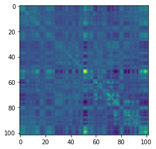

```python
n_rep = len(data[:,0,0])

X_cov = np.zeros(shape = (102, 102))

for rep in range(0, n_rep):
    X_cov += data[rep, :, : ] @ data[rep, :, : ].T

X_cov = X_cov/n_rep

#new.shape

#test = (1/n_rep)*np.matmul(X, X.T)

#len(test)
plt.imshow(X_cov)
```

**iv. Make an average over the repetition dimension using `np.mean` - use the `axis` argument. (The resulting array should have two dimensions with time as the first and magnetic field as the second)**

```python
data_mean = data.mean(axis = 0)

# first dimension should be time and second should be sensors (magnetic field)
data_mean = data_mean.swapaxes(0,1)
```

**v. Plot the magnetic field (based on the average) as it evolves over time for each of the sensors (a line for each) (time on the x-axis and magnetic field on the y-axis). Add a horizontal line at $y = 0$ and a vertical line at $x = 0$ using `plt.axvline` and `plt.axhline`**

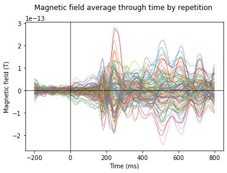

```python
plt.plot(times, data_mean, linewidth = .5)
plt.axvline(x = 0, color = 'black', linewidth = .7)
plt.axhline(y = 0, color = 'black', linewidth = .7)
plt.xlabel('Time (ms)')
plt.ylabel('Magnetic field (T)')
plt.title('Magnetic field average through time by repetition \n')
plt.show()
```

**vi. Find the maximal magnetic field in the average. Then use `np.argmax` and `np.unravel_index` to find the sensor that has the maximal magnetic field.**

```python
mag_max = np.argmax(data_mean)

print(np.unravel_index(mag_max, (251, 102)))

max_av = data_mean[112, 73]
# repetiton 112, sensor 73

print(f'Maximal magnetic field in the average: \n {max_av}')
```

```
(112, 73)
Maximal magnetic field in the average:
 2.7886216843591933e-13
```

```python
sensor = data[:, 73 , ]
sensor.shape
# rep , sensor, times
```

```
(682, 251)
```

**vii. Plot the magnetic field for each of the repetitions (a line for each) for the sensor that has the maximal magnetic field. Highlight the time point with the maximal magnetic field in the average (as found in 1.1.v) using `plt.axvline`**

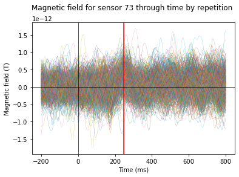

```python
for i in range(0, n_rep):
    sensor = data[i, 73, :]
    plt.plot(times, sensor, linewidth = .2)
plt.axvline(x = times[112], color = 'red')
plt.axvline(x = 0, color = 'black', linewidth = .7)
plt.axhline(y = 0, color = 'black', linewidth = .7)
plt.xlabel('Time (ms)')
plt.ylabel('Magnetic field (T)')
plt.title('Magnetic field for sensor 73 through time by repetition \n')
plt.show()
```

**viii. Describe in your own words how the response found in the average is represented in the single repetitions. But do make sure to use the concepts *signal* and *noise* and comment on any differences on the range of values on the y-axis**

From the average, we are able to detect sensors that in general might be relevant for identifying activation areas, whereas we are also be able to discard sensors without much signal on average.

**2) Now load `pas_vector.npy` (call it `y`). PAS is the same as in Assignment 2, describing the clarity of the subjective experience the subject reported after seeing the briefly presented stimulus**

```python
y = np.load('pas_vector.npy')
```

**i. Which dimension in the `data` array does it have the same length as?**

```python
print(data.shape)

print(len(y))
```

```
(682, 102, 251)
682
```

It has the same shape as the first dimension, which is the repetition

**ii. Now make four averages (As in Exercise 1.1.iii), one for each PAS rating, and plot the four time courses (one for each PAS rating) for the sensor found in Exercise 1.1.vi**

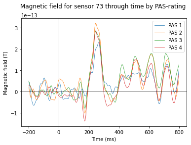

```python
sensor_73 = data[:, 73, :]

pas_1 = sensor_73[np.where((y == 1))]
pas_2 = sensor_73[np.where((y == 2))]
pas_3 = sensor_73[np.where((y == 3))]
pas_4 = sensor_73[np.where((y == 4))]

pas_1_mean = pas_1.mean(axis = 0)
pas_2_mean = pas_2.mean(axis = 0)
pas_3_mean = pas_3.mean(axis = 0)
pas_4_mean = pas_4.mean(axis = 0)

plt.plot(times, pas_1_mean, linewidth = .7)
plt.plot(times, pas_2_mean, linewidth = .7)
plt.plot(times, pas_3_mean, linewidth = .7)
plt.plot(times, pas_4_mean, linewidth = .7)
plt.axvline(x = 0, color = 'black', linewidth = .7)
plt.axhline(y = 0, color = 'black', linewidth = .7)
plt.title('Magnetic field for sensor 73 through time by PAS-rating \n')
plt.legend(['PAS 1', 'PAS 2', 'PAS 3', 'PAS 4'])
plt.xlabel('Time (ms)')
plt.ylabel('Magnetic field (T)')
plt.show()
```

**iii. Notice that there are two early peaks (measuring visual activity from the brain), one before 200 ms and one around 250 ms. Describe how the amplitudes of responses are related to the four PAS-scores. Does PAS 2 behave differently than expected?**

PAS 1 seems to have a much smaller amplitude for both peaks. This could be explained by the fact that the target wasn't seen and therfore less information had to be processed. PAS 2 does not seem to behave very differently PAS 3 and PAS 4 - actually having the strongest signal for the second peak, which we might have expected for PAS 4. This could be explained by the fact that there is less information to work with and therefore the little amount of information is processed to a higher extend.

### EXERCISE 2 - Do logistic regression to classify pairs of PAS-ratings

**1) Now, we are going to do Logistic Regression with the aim of classifying the PAS-rating given by the subject**

**i. We'll start with a binary problem - create a new array called `data_1_2` that only contains PAS responses 1 and 2. Similarly, create a `y_1_2` for the target vector**

```python
pas_vector = np.load('pas_vector.npy')
```

```python
data_1_2 = data[np.where((pas_vector == 1) | (pas_vector == 2))]

y_1_2 = pas_vector[np.where((pas_vector == 1) | (pas_vector == 2))]
```

```python
data_1_2.shape
```

```
(214, 102, 251)
```

**ii. Scikit-learn expects our observations (`data_1_2`) to be in a 2d-array, which has samples (repetitions) on dimension 1 and features (predictor variables) on dimension 2. Our `data_1_2` is a three-dimensional array. Our strategy will be to collapse our two last dimensions (sensors and time) into one dimension, while keeping the first dimension as it is (repetitions). Use `np.reshape` to create a variable `X_1_2` that fulfils these criteria.**

```python
X_1_2 = np.reshape(data_1_2, newshape = (214, 102*251))
X_1_2.shape
```

```
(214, 25602)
```

**iii. Import the `StandardScaler` and scale `X_1_2`**

```python
from sklearn.preprocessing import StandardScaler

sc_x = StandardScaler()

X_1_2_sc = sc_x.fit_transform(X_1_2)
```

**iv. Do a standard `LogisticRegression` - can be imported from `sklearn.linear_model` - make sure there is no `penalty` applied**

```python
from sklearn.linear_model import LogisticRegression

regressor = LogisticRegression(penalty='none')

m_none = regressor.fit(X_1_2_sc, y_1_2)

len(m_none.coef_[0])
```

```
25602
```

**v. Use the `score` method of `LogisticRegression` to find out how many labels were classified correctly. Are we overfitting? Besides the score, what would make you suspect that we are overfitting?**

```python
m_none.score(X_1_2_sc, y_1_2)
```

```
1.0
```

It looks like everything got classified correctly, so we might be overfitting.

**vi. Now apply the *L1* penalty instead - how many of the coefficients (`.coef_`) are non-zero after this?**

```python
# choosing the liblinear solver as 'saga' did not converge
regressor_l1 = LogisticRegression(penalty='l1', solver = 'liblinear')

m_l1 = regressor_l1.fit(X_1_2_sc, y_1_2)

coefs = m_l1.coef_.flatten()
non_zero = coefs != 0

np.unique(non_zero)
```

```
array([False,  True])
```

**vii. Create a new reduced $X$ that only includes the non-zero coefficients - show the covariance of the non-zero features (two covariance matrices can be made; $X_{reduced}X_{reduced}^T$ or $X_{reduced}^TX_{reduced}$ (you choose the right one)) . Plot the covariance of the features using `plt.imshow`. Compared to the plot from 1.1.iii, do we see less covariance?**

```python
X_red = X_1_2_sc[:,non_zero]
```

```python
X_red.shape
```

```
(214, 282)
```

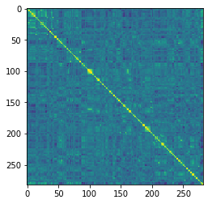

```python
X_red_cov = X_red.T @ X_red #transform first, we want a 282x282 matrix - in relation to the features

plt.imshow(X_red_cov)
```

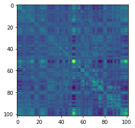

```python
#plot from 1.1iii
plt.imshow(X_cov)
```

It might look like there is more covariance in (a greater amount of green), compared to the plot from 1.1.ii.

**2) Now, we are going to build better (more predictive) models by using cross-validation as an outcome measure**

**i. Import `cross_val_score` and `StratifiedKFold` from `sklearn.model_selection`**

```python
from sklearn.model_selection import cross_val_score, StratifiedKFold
```

**ii. To make sure that our training data sets are not biased to one target (PAS) or the other, create `y_1_2_equal`, which should have an equal number of each target. Create a similar `X_1_2_equal`. The function `equalize_targets_binary` in the code chunk associated with Exercise 2.2.ii can be used. Remember to scale `X_1_2_equal`!**

```python
def equalize_targets_binary(data, y):
    np.random.seed(7)
    targets = np.unique(y) ## find the number of targets
    if len(targets) > 2:
        raise NameError("can't have more than two targets")
    counts = list()
    indices = list()
    for target in targets:
        counts.append(np.sum(y == target)) ## find the number of each target
        indices.append(np.where(y == target)[0]) ## find their indices
    min_count = np.min(counts)
    # randomly choose trials
    first_choice = np.random.choice(indices[0], size=min_count, replace=False)
    second_choice = np.random.choice(indices[1], size=min_count,replace=False)

    # create the new data sets
    new_indices = np.concatenate((first_choice, second_choice))
    new_y = y[new_indices]
    new_data = data[new_indices, :, :]

    return new_data, new_y


eq = equalize_targets_binary(data_1_2, y_1_2)

X_1_2_eq = eq[0]
y_1_2_eq = eq[1]

X_1_2_equal = np.reshape(X_1_2_eq, newshape=(198, 102*251))
X_1_2_e_sc = sc_x.fit_transform(X_1_2_equal)

X_1_2_e_sc.shape
```

```
(198, 25602)
```

**iii. Do cross-validation with 5 stratified folds doing standard `LogisticRegression` (See Exercise 2.1.iv)**

```python
regressor_cv = LogisticRegression(penalty='none')

regressor_cv.fit(X_1_2_e_sc, y_1_2_eq)

s_kfold = StratifiedKFold(n_splits = 5)

X_cv = cross_val_score(regressor_cv, X_1_2_e_sc, y_1_2_eq, cv = s_kfold)

np.mean(X_cv)
```

```
0.5353846153846155
```

**iv. Do L2-regularisation with the following `Cs= [1e5, 1e1, 1e-5]`. Use the same kind of cross-validation as in Exercise 2.2.iii. In the best-scoring of these models, how many more/fewer predictions are correct (on average)?**

```python
cs = [1e5, 1e1, 1e-5]

for i in range(len(cs)):
    regressor_l2 = LogisticRegression(penalty='l2', solver = 'lbfgs', C = cs[i])

    regressor_l2.fit(X_1_2_e_sc, y_1_2_eq)

    X_cv_iv = cross_val_score(regressor_l2, X_1_2_e_sc, y_1_2_eq, cv = s_kfold)

    print(np.round(np.mean(X_cv_iv), 4))
```

```
0.5354
0.5253
0.5956
```

Looks like the logistic regression with the lowest C-value, 1e-5, is the best-scoring model, since it has the highest accuracy.

**v. Instead of fitting a model on all `n_sensors * n_samples` features, fit a logistic regression (same kind as in Exercise 2.2.iv (use the `C` that resulted in the best prediction)) for **each** time sample and use the same cross-validation as in Exercise 2.2.iii. What are the time points where classification is best? Make a plot with time on the x-axis and classification score on the y-axis with a horizontal line at the chance level (what is the chance level for this analysis?)**

```python
regressor_l2_c = LogisticRegression(penalty='l2', solver = 'lbfgs', C = 1e-5)

ok = np.zeros(shape = (251))

for i in range(0, 251):
    X_1_2_time = X_1_2_eq[:, :, i]
    X_1_2_time = sc_x.fit_transform(X_1_2_time)
    model_r = regressor_l2_c.fit(X_1_2_time, y_1_2_eq)

    X_here = cross_val_score(model_r, X_1_2_time, y_1_2_eq, cv = s_kfold)
    X_here_m = np.mean(X_here)

    ok[i] = X_here_m
```

```
Highest classification score: 0.6149 at 232 ms.
```

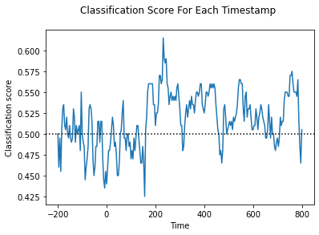

```python
max_0 = np.argmax(ok) # Finding the index with the highest classification accuracy

max_ok_0 = ok[max_0] # Finding the actual classification score

print(f'Highest classification score: {np.round(max_ok_0, 4)} at {times[max_0]} ms.')

plt.plot(times, ok)
#plt.axvline(x = times[max_0], color = 'red')
plt.axhline(y = .5, color = 'black', linestyle = ':')
plt.title('Classification Score For Each Timestamp \n')
plt.xlabel('Time')
plt.ylabel('Classification score')
plt.show()
```

For a binary outcome, the baseline (Zero Rate) accuracy is approximately 50%. In relation to the *perfomance* of a classifier/prediction, it can be discussed whether it should be around .55 - this is on the basis of the fact that a performance with a classification accuracy of e.g. 0.51 not often would be sufficient enough for convincing that the classifier is performing above chance, because the 1 percent point from .5 cuold just be noise. In general, cassification score need to be way chance before people dare labelling them as 'performing well' and 'above chance'.

**vi. Now do the same, but with L1 regression - set `C=1e-1` - what are the time points when classification is best? (make a plot)?**

```python
regressor_l1_c = LogisticRegression(penalty='l1', solver = 'liblinear', C = 1e-1)
```

```python
ok_1 = np.zeros(shape = (251))

for i in range(0, 251):
    X_1_2_time = X_1_2_eq[:, :, i]
    X_1_2_time = sc_x.fit_transform(X_1_2_time)
    regressor_l1_c.fit(X_1_2_time, y_1_2_eq)
    X_here = cross_val_score(regressor_l1_c, X_1_2_time, y_1_2_eq, cv = s_kfold)
    X_here_m = np.mean(X_here)

    ok_1[i] = X_here_m
```

```
Highest classification score: 0.6720512820512822 at 244 ms.
```

[figure not shown]

```python
max_1 = np.argmax(ok_1, axis = 0)
max_ok_1 = ok_1[max_1]

print(f'Highest classification score: {max_ok_1} at {times[max_1]} ms.')

plt.plot(times, ok_1, color = 'green')
plt.axvline(x = times[111], color = 'red', linewidth = 1)
plt.show()
```

**vii. Finally, fit the same models as in Exercise 2.2.vi but now for `data_1_4` and `y_1_4` (create a data set and a target vector that only contains PAS responses 1 and 4). What are the time points when classification is best? Make a plot with time on the x-axis and classification score on the y-axis with a horizontal line at the chance level (what is the chance level for this analysis?)**

```python
data_1_4 = data[np.where((pas_vector == 1) | (pas_vector == 4))]

y_1_4 = pas_vector[np.where((pas_vector == 1) | (pas_vector == 4))]

eq_1_4 = equalize_targets_binary(data_1_4, y_1_4)
X_1_4_eq = eq_1_4[0]
y_1_4_eq = eq_1_4[1]

print(X_1_4_eq.shape)
```

```
(198, 102, 251)
```

```python
ok_2 = np.zeros(shape = (251))

for i in range(0, 251):
    X_1_4_new = X_1_4_eq[:, :, i]
    X_1_4_time = sc_x.fit_transform(X_1_4_new)
    regressor_l1_c.fit(X_1_4_time, y_1_4_eq)
    X_here = cross_val_score(regressor_l1_c, X_1_4_time, y_1_4_eq, cv = s_kfold)
    X_here_m = np.mean(X_here)
    ok_2[i] += X_here_m
```

```
109
Highest classification score: 0.6423 at 236 ms.
```

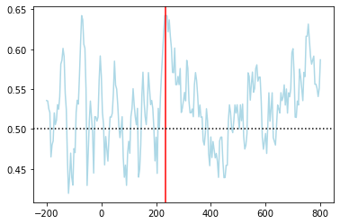

```python
max_ok_2 = np.argmax(ok_2, axis = 0)
print(max_ok_2)

max_av_ok_2 = ok_2[max_ok_2]

print(f'Highest classification score: {round(max_av_ok_2, 4)} at {times[max_ok_2]} ms.')

plt.plot(times, ok_2, color = 'lightblue')
plt.axvline(x = times[max_ok_2], color = 'red')
plt.axhline(y = .5, color = 'black', linestyle = ':')
plt.show()
```

**3) Is pairwise classification of subjective experience possible? Any surprises in the classification accuracies, i.e. how does the classification score fore PAS 1 vs 4 compare to the classification score for PAS 1 vs 2?**

```python
print(np.mean(ok_1), np.mean(ok_2))
```

```
0.5234717540096027 0.5269077536009807
```

### EXERCISE 3 - Do a Support Vector Machine Classification on all four PAS-ratings

**1) Do a Support Vector Machine Classification**

**i. First equalize the number of targets using the function associated with each PAS-rating using the function associated with Exercise 3.1.i**

```python
def equalize_targets(data, y):
    np.random.seed(7)
    targets = np.unique(y)
    counts = list()
    indices = list()
    for target in targets:
        counts.append(np.sum(y == target))
        indices.append(np.where(y == target)[0])
    min_count = np.min(counts)
    first_choice = np.random.choice(indices[0], size=min_count, replace=False)
    second_choice = np.random.choice(indices[1], size=min_count, replace=False)
    third_choice = np.random.choice(indices[2], size=min_count, replace=False)
    fourth_choice = np.random.choice(indices[3], size=min_count, replace=False)

    new_indices = np.concatenate((first_choice, second_choice,
                                 third_choice, fourth_choice))
    new_y = y[new_indices]
    new_data = data[new_indices, :, :]

    return new_data, new_y
```

```python
eq = equalize_targets(data, pas_vector)

X_all_eq = eq[0]
y_all_eq = eq[1]

print(X_all_eq.shape, '\n', y_all_eq.shape)
```

```
(396, 102, 251)
 (396,)
```

**ii. Run two classifiers, one with a linear kernel and one with a radial basis (other options should be left at their defaults) - the number of features is the number of sensors multiplied the number of samples. Which one is better predicting the category?**

```python
cv = StratifiedKFold(n_splits = 5)

X = np.reshape(X_all_eq, newshape=(396, 102*251))

sc = StandardScaler()

X_std = sc.fit_transform(X)
```

```python
from sklearn.svm import SVC
```

```python
svm_l = SVC(kernel='linear') ## try to set it low

scores_svm_l = cross_val_score(svm_l, X_std, y_all_eq, cv=cv)

print(f'Precision score using linear kernel: {round(np.mean(scores_svm_l), 4)}')
```

```
Precision score using linear kernel: 0.2928
```

```python
svm_rbf = SVC(kernel='rbf')

scores_svm_rbf = cross_val_score(svm_rbf, X_std, y_all_eq, cv=cv)

print(f'Precision score using Radial Basis Function: {np.round(np.mean(scores_svm_rbf), 4)}')
```

```
Precision score using Radial Basis Function: 0.3334
```

Looks like the Radial Basis function is better at predicting category.

**iii. Run the sample-by-sample analysis (similar to Exercise 2.2.v) with the best kernel (from Exercise 3.1.ii). Make a plot with time on the x-axis and classification score on the y-axis with a horizontal line at the chance level (what is the chance level for this analysis?)**

[figure not shown]

```python
e3_iii = np.zeros(shape = (251))

for i in range(0, 251):
    X_sample = X_all_eq[:, :, i]
    X_sample_std = sc_x.fit_transform(X_sample)

    scores_svm_rbf = cross_val_score(svm_rbf, X_sample_std, y_all_eq, cv=cv)
    X_here_mean = np.mean(scores_svm_rbf)

    e3_iii[i] = X_here_mean


plt.plot(times, e3_iii)
plt.axhline(y = 0.25, color = 'black', linestyle = ':')
plt.title('Classification score of PAS 1 versus PAS 4')
plt.xlabel('Time (ms)')
plt.ylabel('Classification score (prob)')
plt.show()
```

**iv. Is classification of subjective experience possible at around 200-250 ms?**

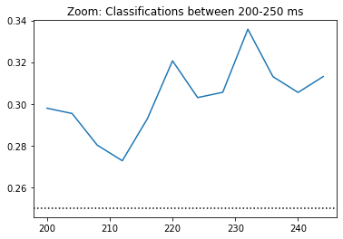

```
Number of classifications between 200-250 ms above chance level (0.25): 12 out of 12
```

```python
cut_e3 = e3_iii[100:100+round(50/4)]
cut_times = times[100:100+round(50/4)]

plt.plot(cut_times, cut_e3)
plt.axhline(y = 0.25, color = 'black', linestyle = ':')
plt.title('Zoom: Classifications between 200-250 ms')
plt.show()

cut_e3 = cut_e3 >= 0.25

ar_unique, i = np.unique(cut_e3, return_counts=True)

print(f'Number of classifications between 200-250 ms above chance level (0.25): {i[0]} out of {len(cut_e3)}')
```

All classifications scores in between 200-250 ms are above chance level (0.25), however, it it could be doubted whether an accuracy score around 0.3 could be accepted as high performance.

**2) Finally, split the equalized data set (with all four ratings) into a training part and test part, where the test part is 30 % of the trials. Use `train_test_split` from `sklearn.model_selection`**

```python
from sklearn.model_selection import train_test_split

X_train, X_test, y_train, y_test = train_test_split(X, y_all_eq, test_size=0.3,
                                                    random_state=0)

X_train_std = sc.fit_transform(X_train)
X_test_std = sc.fit_transform(X_test)
```

**i. Use the kernel that resulted in the best classification in Exercise 3.1.ii and `fit`the training set and `predict` on the test set. This time your features are the number of sensors multiplied by the number of samples.**

```python
# Using the radial basis kernel

svc = SVC(kernel='rbf')

svc.fit(X_train_std, y_train)

y_predict = svc.predict(X_test_std)
```

**ii. Create a *confusion matrix*. It is a 4x4 matrix. The row names and the column names are the PAS-scores. There will thus be 16 entries. The PAS1xPAS1 entry will be the number of actual PAS1, $y_{pas1}$ that were predicted as PAS1, $\hat y_{pas1}$. The PAS1xPAS2 entry will be the number of actual PAS1, $y_{pas1}$ that were predicted as PAS2, $\hat y_{pas2}$ and so on for the remaining 14 entries. Plot the matrix**.

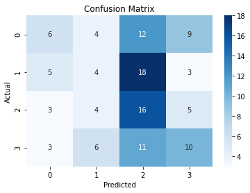

```python
from sklearn.metrics import classification_report, confusion_matrix

cm = confusion_matrix(y_true = y_test, y_pred = y_predict)

import seaborn as sns

plt.figure()
heatmap = sns.heatmap(cm, annot=True, cmap='Blues')
heatmap.set_title('Confusion Matrix')
heatmap.set_ylabel('Actual')
heatmap.set_xlabel('Predicted')
plt.show()
```

```python
print(classification_report(y_test, y_predict))
```

```
              precision    recall  f1-score   support

           1       0.35      0.19      0.25        31
           2       0.22      0.13      0.17        30
           3       0.28      0.57      0.38        28
           4       0.37      0.33      0.35        30

    accuracy                           0.30       119
   macro avg       0.31      0.31      0.29       119
weighted avg       0.31      0.30      0.28       119
```

**iii. Based on the confusion matrix, describe how ratings are misclassified and if that makes sense given that ratings should measure the strength/quality of the subjective experience. Is the classifier biased towards specific ratings?**

The classifier seems to be biased towards PAS 3. It might make sense, because 2, 3 and 4 do not to differ a lot in the measurements, and then it tends to classify as PAS 3 (*'in between PAS 2 and 4'* as to say).